# Numerical Integration

## 1. Quadrature method (구적법)

수치적분(numerical interation)은 어떤 함수 $f$의 적분

$\int_a^b f(x) d x$

를 근사하기 위한 것이다. 수치적분이 필요한 이유는 다음과 같다.

- f의 정적분 형태가 존재하지 않거나 계산이 어려울 수 있다.
- f가 유한개의 점 $x_i,~i=1,\ldots,n$에서만 측정되었을 수 있다. (샘플링의 문제 등)

구적법은 단변량 함수의 적분을 위한 가장 긴 역사를 가진 방법이라 할 수 있으며 보간법에 기초하고 있다. 근사의 정확도를 높이기 위한 다양한 방법들이 제안되어져 왔으나 본 강의에서는 기본적인 개념만 다루도록 한다.

#### 1.1 midpoint rule

다음과 같이 적분을 근사하는 방식이다.

$\int_a^b f(x) d x \approx (b-a)f(\frac{a+b}{2})$

가장 간단한 형태이고 $f$가 상수함수에 가까울 수록 좋은 근사를 한다.

#### 1.2 trapezoidal rule

다음과 같이 적분을 근사하는 방식이다.

$\int_a^b f(x) d x \approx (b-a)\frac{f(a)+f(b)}{2}.$

#### 1.3 composite rules

적분구간인 (a,b)을 여러 구간으로 분할하여 각각 위 법칙들을 적용한다면 더 좋은 근사값을 얻을 수 있을 것이다. 즉 $(a,b)=\cup_{i=1}^k (a_{i-1},a_i),~a_0=a,~a_k=b$와 같이 분할 한다면, trapezoidal rule의 경우에는

$\int_a^b f(x) d x \approx \sum_{i=1}^{k} (a_i-a_{i-1})\frac{f(a_{i-1})+f(a_i)}{2}$

와 같이 근사가 가능하다. $h=a_i-a_{i-1}$와 같이 구간을 등간격으로 분할하면 위 식은 더 간단해 진다.

만약, 수치적분의 근사를 더 정확하게 하고자 한다면,

- 구간의 분할을 더 조밀하게 하거나
- 각 구간에서의 보간을 더 높은 차원의 다항식으로 하면 된다.

#### 1.4 Example

1. $\int_0^1 \sin x dx$

```r
a=0;b=1
S_m=function(h)
{
g=seq(a,b,h)
g1=(g+h/2)[-length(g)]
S=h*(sum(sin(g1)))
err=abs(S-(cos(a)-cos(b)))
return(c(S,err))
}
S_t=function(h)
{
g=seq(a,b,h)
S=h*(sum(sin(g))-(sin(a)+sin(b))/2)
err=abs(S-(cos(a)-cos(b)))
return(c(S,err))
}
S_m(0.1);S_m(0.05)
```

```
## [1] 0.4598892907 0.0001915966
```

```
## [1] 4.597456e-01 4.788867e-05
```

```r
S_t(0.1);S_t(0.05)
```

```
## [1] 0.4593145489 0.0003831453
```

```
## [1] 4.596019e-01 9.577434e-05
```

2. Approximation of $\pi$

$\int_0^1 \sqrt{1-x^2} dx = \arcsin (1)/2 = \pi/4$

```r
a=0;b=1
S_pi=function(h)
{
g=seq(a,b,h)
S=h*(sum(sqrt(1-g^2))-(sqrt(1-a^2)+sqrt(1-b^2))/2)
err=abs(S-(pi/4))
return(c(4*S,4*err))
}
S_pi(0.05);S_pi(0.001)
```

```
## [1] 3.12846488 0.01312777
```

```
## [1] 3.141555e+00 3.718668e-05
```

## 2. Monte Carlo integration (MC)

구적법은 정적분을 계산하기 위한 훌륭한 방법이나 다음과 같은 경우에는 적용이 어렵다.

- 다변량 함수의 적분 계산이 필요한 경우
- 적분대상인 함수가 smooth하지 않아 보간법의 적용이 어려운 경우

구적법에서는 fixed points에 근거한 보간법을 이용했다면, MC에서는 random points에 근거하여 적분값을 근사한다. 따라서 random points의 underlying distribution이 근사하는데에 중요한 역할을 하게 된다.

#### 2.1 Representing integral with Expectation

가장 간단한 경우 $f$가 어떤 확률변수 $X$의 pdf라면,

$E(g(X))=\int g(x)f(x)dx$

이고, 만약 $f$로부터 임의표본 $X_1,\ldots,X_n$을 관측했다면, 위 적분값을 $\frac{1}{n}\sum_{i=1}^n g(X_i)$로 근사할 수 있다. 이 근사값이 위의 적분값으로 (확률)수렴한다는 사실은 WLLN(SLLN)로부터 잘 알려진 사실이다.

- Example : Approximation of $\pi$ (revisited)

$\int_0^1 \sqrt{1-x^2} dx = E(\sqrt{1-X^2}),~X\sim U(0,1)$

```r
S_pimc=function(n)
  {
  X=runif(n)
  S=mean(sqrt(1-X^2))
  err=abs(S-pi/4)
  return(c(4*S,4*err))
  }
set.seed(1)
S_pimc(50);S_pimc(200);S_pimc(1000)
```

```
## [1] 3.10358931 0.03800334
```

```
## [1] 3.17138159 0.02978894
```

```
## [1] 3.142793117 0.001200463
```

- 특정분포로부터 표본을 추출하는 과정을 포함하기 때문에 seed에 따라 근사값이 달라질 수 있다.
- 표본의 개수를 늘리면 근사값이 좋아지는 경향이 있지만, 이 또한 표본에 따라 반대의 결과가 나올 수도 있다.
- Example

$\int_0^1\int_0^1 x y dx dy = E(X Y),~X,Y\sim U(0,1)$

```r
S_2=function(n)
  {
  X=runif(n)
  Y=runif(n)
  S=mean(X*Y)
  err=abs(S-1/4)
  return(c(S,err))
  }
set.seed(1)
S_2(50);S_2(200);S_2(1000)
```

```
## [1] 0.2717744 0.0217744
```

```
## [1] 0.23718092 0.01281908
```

```
## [1] 0.244000165 0.005999835
```

#### 2.2 Generating random deviates

위 절에서 적분값의 근사를 위해 특정 분포로부터 표본을 추출하였다. 즉, 임의표본을 추출하는 테크닉 또한 Mc에 근거한 수치적분을 위하여 매우 중요하다.

##### 2.2.1 Inverse method

$X$의 분포함수를 $F$이고, $F$가 역함수가 존재하는 연속함수라 가정하면, $F^{-1}(U)\overset{d}{=}X$이 잘 알려져 있다. 즉, $U(0,1)$에서 표본을 뽑은 후 $F^{-1}$를 취해주는 것으로 $F$에서의 임의표본을 추출할 수 있다.

이 방법은 $F$가 연속이 아닌 경우에도 $F^{-1}$ 를 적절히 정의함에 따라 확장 적용 가능함이 알려져 있다.

- Example

$X$가 평균이 $\mu$인 지수분포일 때, 분포함수와 그 역함수는 각각 $F(x)=1-\exp(-\mu x)$, $F^{-1}(x)=-\frac{1}{\mu}\log(1-x)$이므로, $-\frac{1}{\mu}\log(1-U)$가 평균이 $\mu$인 지수분포를 따르게 된다. 또는, $-\log(1-U)$이 평균이 1인 지수분포이므로 여기에 $\mu$를 곱하면 원하는 양을 얻게 된다.

##### 2.2.2 Acceptance-Rejection method

$X$의 pdf가 $f$이고 본 분포로부터 표본을 추출하는 것이 매우 어려운 경우, 상대적으로 표본추출이 쉬운 분포의 pdf $g$가 $f$의 envelop 으로써 다음과 같이 존재한다면,

$f(x)\leq c g(x),~\forall x,~ c>1$

다음과 같은 절차에 의해 $f$로부터의 표본을 추출할 수 있다.

- step 1 : $g$로부터 $Y$를 추출
- step 2 : $U(0,1)$으로부터 $U$를 추출
- step 3 : $U\leq f(Y)/(cg(X))$이면, $Y$를 accept, 그렇지 않으면 $Y$를 reject
- step 4 : 위 과정을 반복하여 원하는 만큼의 표본의 크기를 얻을 때 까지 함.

이 때, acceptance probablity $p=1/c$ 로 주어짐.

- Example : generating $Beta(4,3)$

$X\sim Beta(4,3)$이면, $f(x)=60x^3(1-x)^2I(0\leq x\leq 1)$이다.

$f$의 mode는 $0.6$에서 형성되고 $f(0.6)=2.0736$이므로, $g(x)=1$ 즉, 균등분포를 envelop 함수로 설정하면,

$f(x)\leq 2.0736 \cdot g(x)$

임을 알 수 있다.

```r
set.seed(1)
i=0;X=c();n=0
pdf=function(x){60*x^3*(1-x)^2}
while(n<500)
  {
  i=i+1
  Y=runif(1);U=runif(1)
  if (U < pdf(Y)/(2.0736) ) X[i]=Y
  else X[i]=-1
  n=sum(X>0)
  }
rX=X[X>0];n/length(X);1/2.0736
```

```
## [1] 0.4659832
```

```
## [1] 0.4822531
```

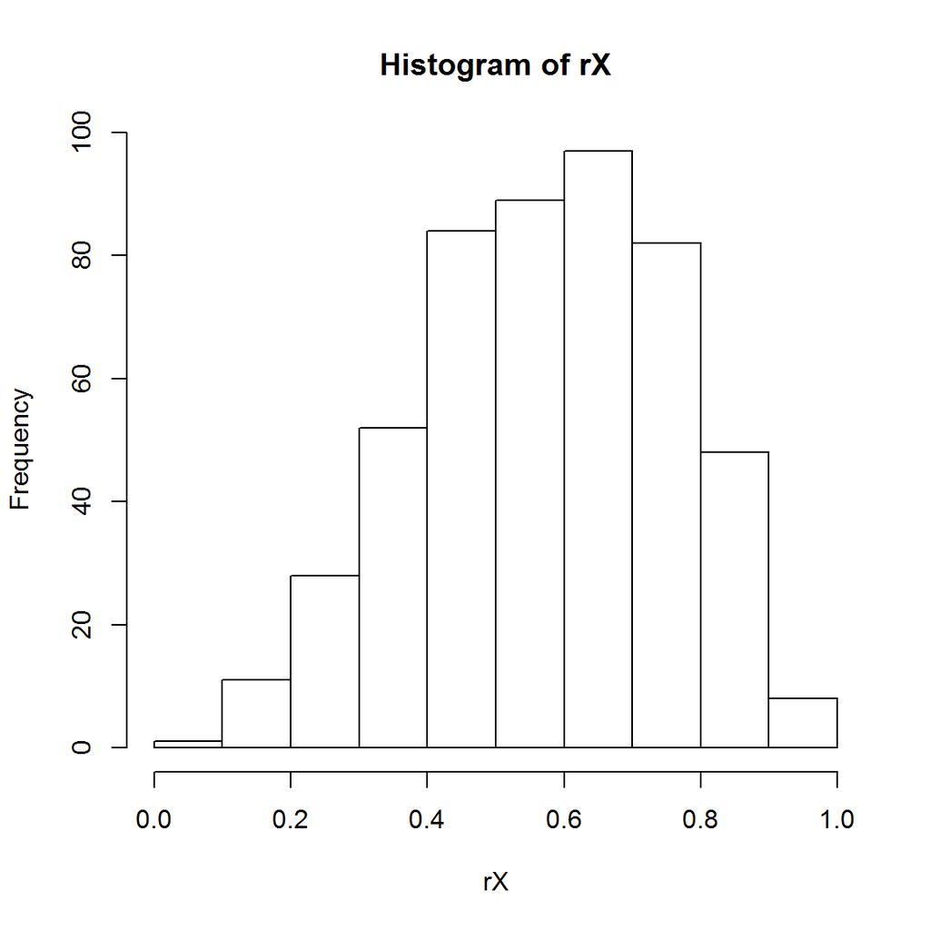

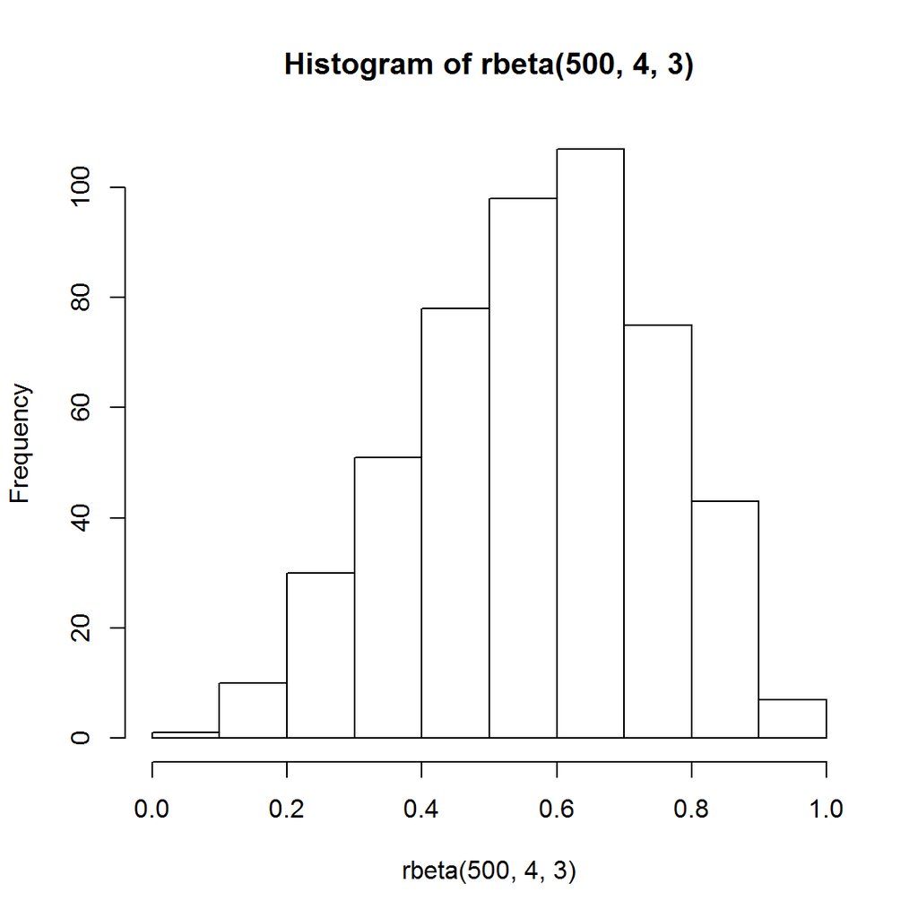

```r
hist(rX);hist(rbeta(500,4,3))
```

(HW) Envelop 함수를 바꾸어서 같은 분포에서 표본뽑기 #22.11.18

##### 2.2.3 Generating by definition

많은 분포는 좀 더 간단한 다른 분포를 따르는 확률변수들의 결합에 의한 분포로 정의될 수 있다. 이를 이용하여 표본을 추출할 수 있다.

- Mixture

$f(x)=\sum_{k=1}^m \alpha_j f_j(x)$을 pdf로 가지는 분포로부터의 표본을 추출하려면, $\alpha_j$의 비율로부터 index $j$를 선택하고(다항선택문제) 선택된 $j$에 대하여 $f_j$로부터 표본을 추출하면 된다.

- 이항분포 성공확률이 $p$인 베르누이 확률변수의 합으로 표현 가능하므로

$S=\sum_{i=1}^n I(U_i\leq p)$

로 정의할 수 있다.

- Lognormal

$\log X\sim N(\mu,\sigma^2)$ 이므로, 표준정규분포로부터 뽑은 표본 $Z$에 대하여 $\exp(\sigma Z +\mu)$로 추출할 수 있다.

- Beta 분포

서로 독립이고 scale parameter가 같은 두 gamma 확률변수 $X_\alpha$, $X_\beta$에 대하여 $X_\alpha/(X_\alpha+X_\beta)$가 $Beta(\alpha,\beta)$이다.

- 다변량정규분포

평균이 $\mu$이고 공분산 행렬이 $\Sigma$인 다변량 정규분포로부터의 표본은, $Z\sim N(0,I)$에 대하여 $\Sigma^{1/2} Z + \mu$에 의해 추출할 수 있다. 여기서 $\Sigma^{1/2}\Sigma^{1/2}=\Sigma$이다.

#### 2.3 Importance sampling

본래의 분포가 아닌 대체 분포로부터 표본을 추출함으로써 적분을 근사하는 테크닉이다.

- 본래의 분포로부터 표본을 뽑는 것이 어렵거나
- 가능하더라도 효율적이지 않을 경우

활용가능한 방법이다.

$E(f(X))=\int f(x)g(x) dx$

에서 $g$와 support를 공유하는 (최소한 더 큰 support를 가지는) 분포함수 $h$를 고려하면,

$E(f(X))=\int f(x)g(x) dx = \int \frac{f(x)g(x)}{h(x)}h(x)dx=E(\frac{f(x)g(x)}{h(x)})$

와 같이 쓸 수 있다. 즉, $h$로부터의 표본을 뽑는 다면

$E(\frac{f(x)g(x)}{h(x)}) \approx \frac{1}{n}\sum_{i=1}^n \frac{f(X_i)g(X_i)}{h(X_i)}$

와 같이 적분을 근사할 수 있다. 여기서 $\frac{g(X_i)}{h(X_i)}$를 importance weight라 한다.

- Example

$[0,1]$에서 절단시킨 표준정규확률변수 $Z$를 고려하자. 즉, pdf는

$f(z)=\frac{\phi(z)}{\int_0^1 \phi(z)dz},~\phi(\cdot):pdf~of~N(0,1)$

와 같이 된다. 만약 $E(Z)$를 계산하기 원한다면,

- method 1

표준정규분포로부터 표본을 뽑은 뒤 $[0,1]$ 안에 존재하는 것들만 남겨두고 버린 후 남겨진 표본의 표본평균으로 근사

- method 2

$\int_0^1 z f(z) dz = E\left(U \frac{\phi(U)}{\int_0^1 \phi(z) dz}\right),~U\sim U(0,1)$

이므로 $\frac{1}{n}\sum_{i=1}^n U_i \frac{\phi(U_i)}{\int_0^1 \phi(z) dz}$로 근사.

이렇게 두 가지를 고려할 수 있다. 이 때, method 1은 $[0,1]$ 바깥에 떨어지는 표본들은 버려야 하므로 $\Phi(1)-\Phi(0)=0.3413$ 만큼의 표본들만 살아남게 되는 한 편, method 2는 버리는 표본 없이 모두 사용하게 되므로 상대적으로 효율적이다.

```r
set.seed(1)
n=1000
X=rnorm(n)
rX=X[(0<X)*(X<1)==1];length(rX)
```

```
## [1] 324
```

```r
S1=mean(rX)
U=runif(n)
Y=U*dnorm(U)/(pnorm(1)-pnorm(0))
S2=mean(Y)
S1;S2
```

```
## [1] 0.4901667
```

```
## [1] 0.4511739
```

Importance sampling의 유용한 점 중 하나는 본래 분포에서 희박한 density를 가지는 구간에서의 표본 추출 과정을 개선시킬 수 있다는 점이다. 예를 들어 $X\sim B(m,p)$이고 $x$가 $P(X \geq x)$를 0에 매우 가깝게 만드는 값이라고 가정해 보자. 만약 $B(m,p)$으로부터 $n$개의 표본을 추출하여 $P(X \geq x)\approx (1/n)\sum_{i=1}^n I(X_i \geq x)$에 의해 확률을 추정한다면, 실제로 $X_i \geq x$를 만족하는 표본의 개수는 얼마 되지 않아 좋은 추정 혹은 근사를 하기가 어렵다 (변동성이 매우 클 것이다). 만약 우리가 $p<<q$를 만족하는 성공확률 $q$에 대하여 $B(m,q)$를 대체분포로 활용하여 importance sampling을 적용한다면 상황을 개선시킬 수 있다. 즉, $Y_i\sim B(m,q)$에 대하여

$\frac{1}{n}\sum_{i=1}^n I(Y_i \geq x) (p/q)^{Y_i} ((1-p)/(1-q))^{m-Y_i}$

로 $P(X \geq x)$를 근사할 수 있다. $q$는 가능하면 $x$ 근처에서 많은 mass를 가지도록 설정하는 것이 좋다고 추측할 수 있다.

- (HW) #23.8.1, #23.8.3

## 3. MCMC (Marcov Chain Monte Carlo)

랜덤샘플을 추출하기 원하는 분포를 $\pi$라 할 때, 다음과 같은 경우가 발생할 수 있다.

- $\pi$가 차원이 크거나 복잡한 형태
- $\pi$를 정확히 아는 것이 불가능
- $\pi$로부터 IID 샘플링을 하는 것이 어렵거나 불가능

이러한 경우 MCMC를 이용하여 적분을 근사할 수 있다. 핵심적인 idea는 IID sequence를 Markov sequence로 대체하는 것이다.

#### 3.1 Markov chain

마코프체인이란 다음과 같은 조건을 만족하는 확률변수열을 말한다.

$X_t,~t=1,2,\ldots$와 임의의 사건집합 $A$에 대하여

$P(X_{t+1}\in A|X_1,\ldots,X_t) = P(X_{t+1}\in A|X_t).$

즉, $t+1$ 상태(시점)에서의 분포가 직전상태에만 의존하는 것이다. 이러한 전이를 특정하는 조건부밀도함수 $q(x_{t+1}|x_t)$를 transition kernel이라고 한다.

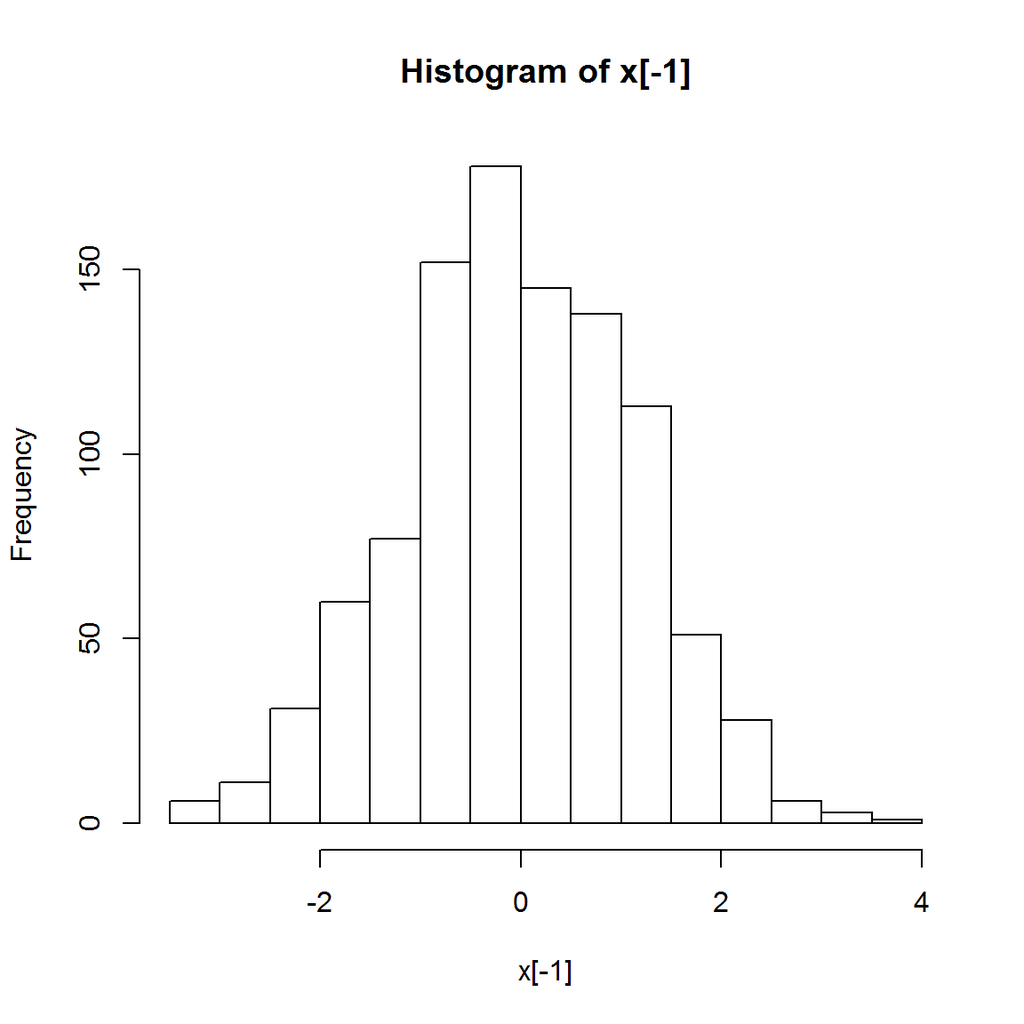

```r
x0=5;x<-x0
set.seed(1)
N=1000
for (i in 1:N)
  {
  x[i+1]=rnorm(1,0.5*x[i],1)
  }
hist(x[-1])
```

만약 $\{X_t\}$가 $\pi$를 정상분포로 가지는 마코프체인이면

$\int f(x) \pi(x) dx \approx \frac{1}{m}\sum_{i=1}^m f(X_t).$

와 같이 근사할 수 있다. 여기서 $m$은 충분히 큰 추출된 마코프열의 개수이며, 첫 $m_0$개는 제외하고 근사에 사용하기도 한다 (초기치의 영향을 줄이고자 하는 의도). 물론 위 근사식은 마코프사슬의 성질에 적절한 가정들이 만족되어야 하며 자세한 내용은 생략한다.

#### 3.2 Metropolis-Hastings algorithm

가장 일반적으로 잘 알려진 방법으로 다음과 같은 절차를 따라 마코프열을 추출한다. 이 방법의 적용을 위해서는 proposal 분포인 $q(\cdot|\cdot)$함수가 필요하며, 이 함수는 샘플의 추출이 쉬운 것으로 보통 선택한다.

- step 1 초기치(상태) $X_0$를 설정한다.
- step 2 proposal distribution으로부터 다음과 같이 $y$를 추출한다. $y\sim q(y|x_t),~t=1,2,\ldots$
- step 3 acceptance probability를 다음과 같이 계산한다. $\alpha(y|x_t)=\min\left\{1,\frac{\pi(y)q(x_t|y)}{\pi(x_t)q(y|x_t)} \right\}$
- step 4 $U\sim U(0,1)$을 추출한다.
- step 5 $U\leq \alpha(y|x_t)$이면 $x_t=y_t$, $U > \alpha(y|x_t)$이면 $x_t=x_{t-1}$

위 과정을 충분히 많은 수($m$)만큼 반복하여 얻은 $X_1,\ldots,X_m$이 정상분포를 $\pi$로 가지는 마코프사슬이 된다. 유념해야 할 점은 정상분포의 normalizing constant는 정확히 알 필요가 없다. 즉, 정상분포의 적절한 상수배의 형태만 정확히 아는 것으로 충분하다.

- Example 1 다음과 같은 정상분포를 가지는 마코프열을 생성해 보자

$\pi(x)=10^xe^{-1}/x!$

proposal 분포를

$q(y|x)=0.5I(|y-x|=1)$

로 설정하면, acceptance probability는

$y=x-1~;~\alpha(x-1|x)=\min(1,x/10)$ $y=x+1~;~\alpha(x+1|x)=\min(1,10/(x+1))$

에 의해 계산된다.

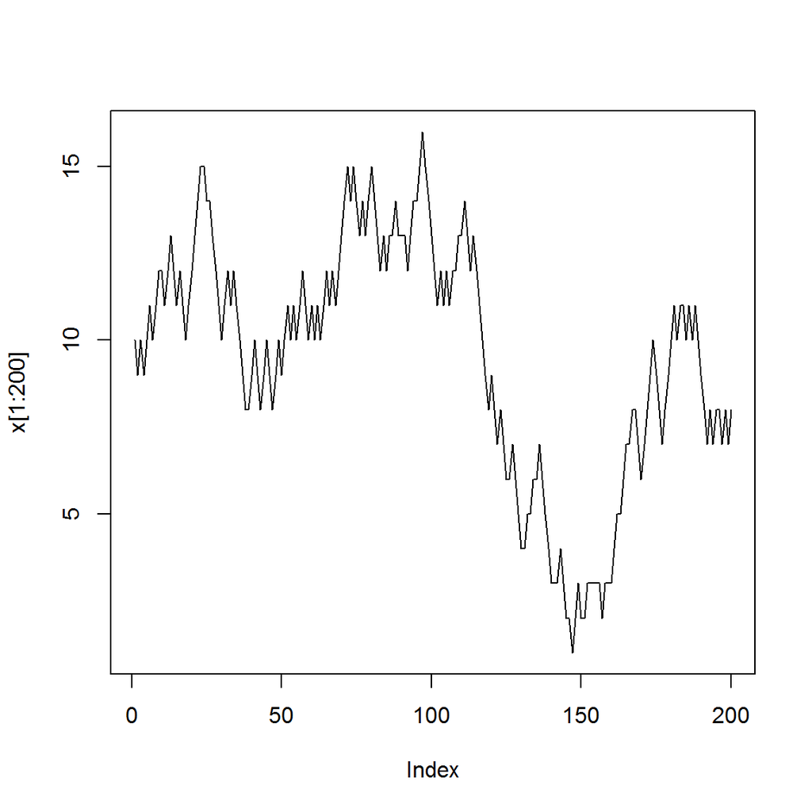

```r
x0=10;x<-x0
set.seed(1)
N=3000
for (i in 1:N)
  {
  y=sample(c(x[i]-1,x[i]+1),1)
  alpha=min(1,x[i]/10)*(y==x[i]-1)+min(1,10/(x[i]+1))*(y==x[i]+1)
  U=runif(1)
  x[i+1]=y*(U<alpha)+x[i]*(U>alpha)
  }
plot(x[1:200],type="l")
```

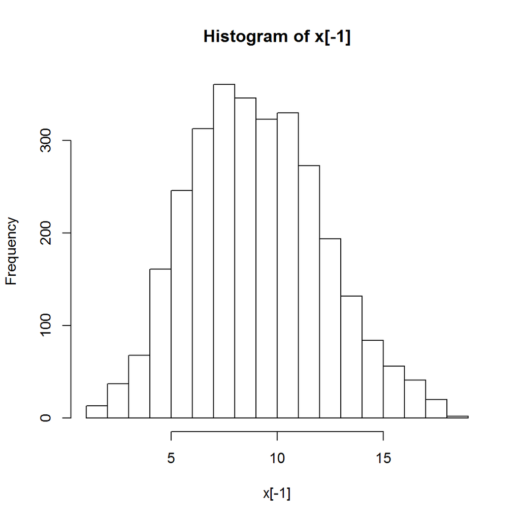

```r
hist(x[-1])
```

```r
mean(x[-1]);var(x[-1])
```

```
## [1] 9.546333
```

```
## [1] 9.972511
```

- Example 2 (random walk MH)

proposal 분포가 $q(y|X)=q(|x-y|)$를 만족하는 경우를 말한다, 이 경우, acceptance probibility는

$\alpha(y|x_t)=\min\left\{1,\frac{\pi(y)}{\pi(x_t)} \right\}$

와 같이 간단해진다.

만약 정상분포가 $N(0,1)$이고 proposal이 $N(x_t,0.5^2)$이면 다음과 같이 구현된다.

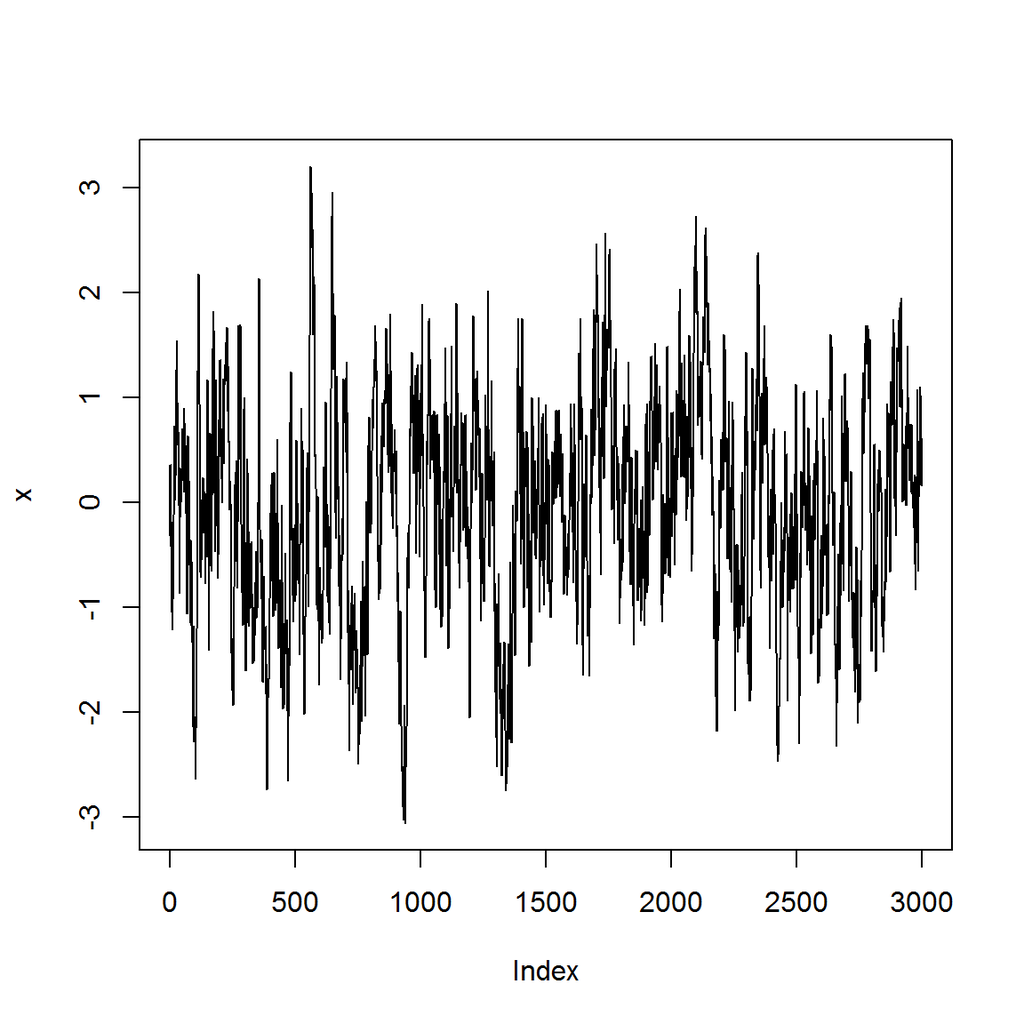

```r
x0=0;x<-x0
set.seed(1)
N=3000
for (i in 1:N)
  {
  y=rnorm(1,x[i],0.5)
  alpha=min(1,dnorm(y)/dnorm(x[i]))
  U=runif(1)
  x[i+1]=y*(U<alpha)+x[i]*(U>alpha)
  }
plot(x,type="l")
```

```r
sum(diff(x)==0)
```

```
## [1] 494
```

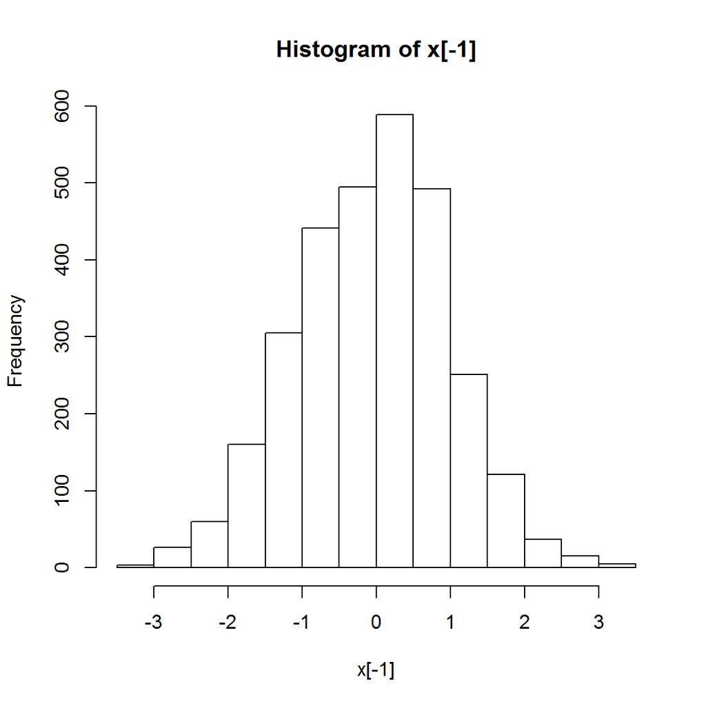

```r
hist(x[-1])
```

```r
mean(x[-1]);var(x[-1])
```

```
## [1] -0.04976925
```

```
## [1] 1.053655
```

- Example 3 (independence sampler)

proposal 분포가 $q(y|X)=q(y)$를 만족하는 경우를 말한다. 즉, proposal 분포가 이전 상태에 관계없이 iid 형태로 추출되게 된다. 비교적 추출이 간단하지만 경우에 따라 샘플링이 매우 잘 되거나 매우 나쁘거나 두 극단으로 나누어지는 것으로 알려져 있으며 proposal이 정상분포에 비해 두터운 꼬리를 가져야 하는 것으로 알려져 있다.

의 형태인 경우 이러한 정상분포를 가지는 마코프열을 Cauchy(1) 분포를 proposal로 하여 다음과 같이 생성할 수 있다.

참고) 본 예는 평균이 $N(\theta,1)$에서 임의표본을 관측하고, prior를 Cauchy(1)으로 두었을 때의 posterior distribution으로부터 마코프열을 추출하고자 하는 과정으로 이해할 수 있다.

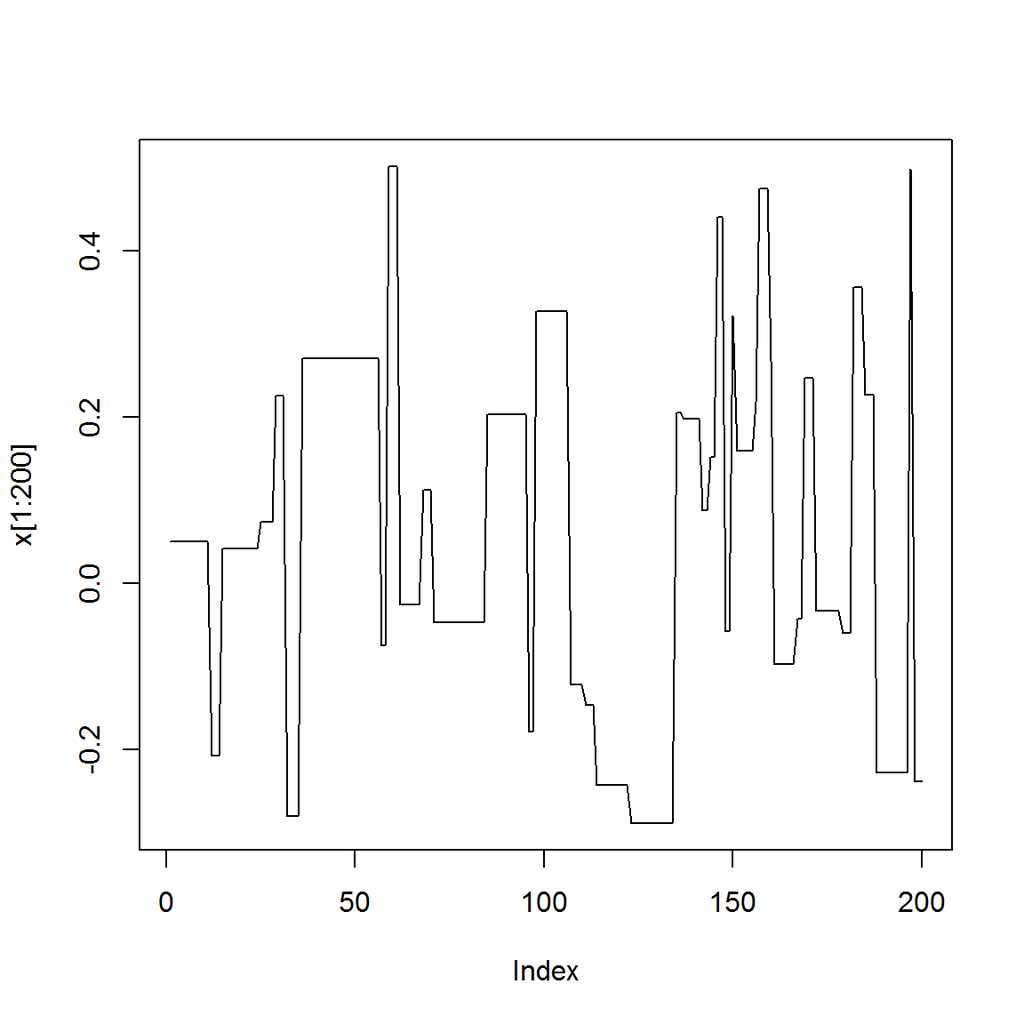

```r
x0=0.05;x<-x0;n=20
set.seed(1)
N=3000
pis=function(x){exp(-n*(x-0.0675)^2/2)/(1+x^2)}
for (i in 1:N)
  {
  y=rcauchy(1)
  alpha=min(1,(pis(y)*dcauchy(x[i]))/(pis(x[i])*dcauchy(y)))
  U=runif(1)
  x[i+1]=y*(U<alpha)+x[i]*(U>alpha)
  }
plot(x[1:200],type="l")
```

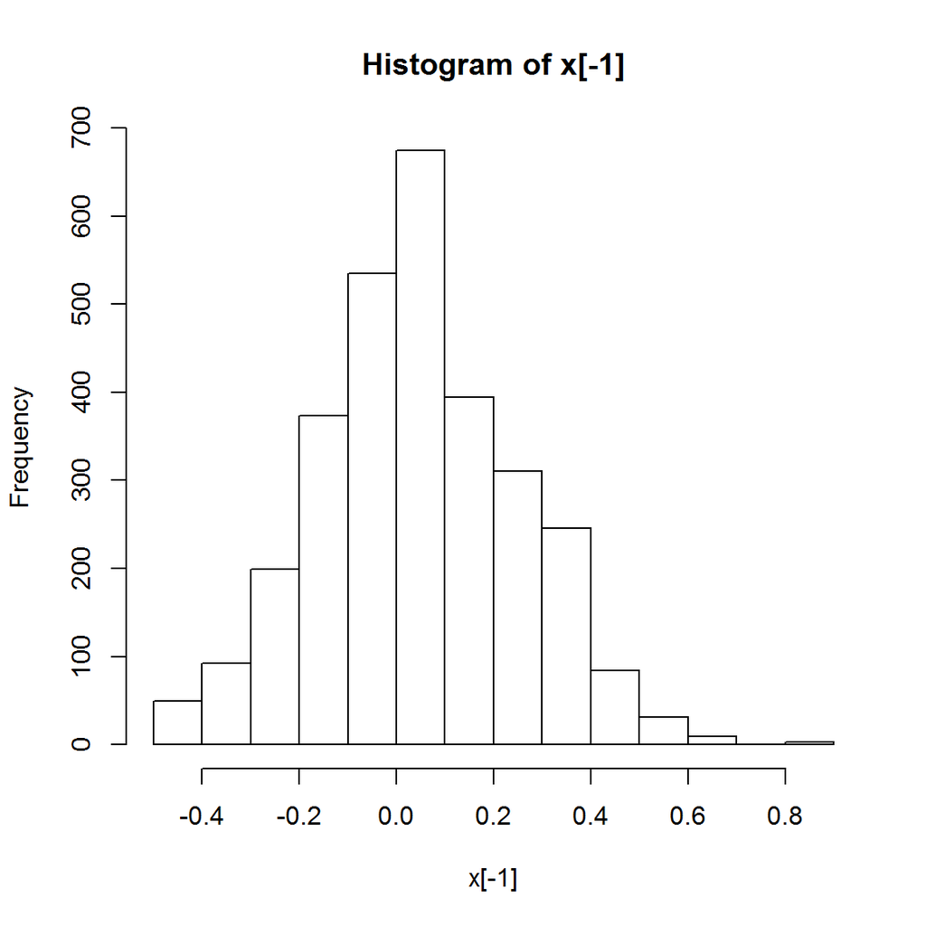

```r
hist(x[-1])
```

```r
mean(x[500:3000]);var(x[500:3000]) # posterior mean & variance
```

```
## [1] 0.04234597
```

```
## [1] 0.04223184
```

#### 3.3 Gibbs sampling algorithm

다변량분포로부터 마코프열을 추출하는 방법으로, 결합분포는 추출이 어렵지만 조건부분포로부터는 상대적으로 추출이 쉬울 경우 유용하다.

- step 1 초기치(상태) $X_0=(X_{10},\ldots,X_{k0})$를 설정한다.
- step 2 다음과 같이 $X_{i,t+1}$를 업데이트한다. $X_{i,t+1}\sim \pi(x_i|x_{1,t+1},\ldots,x_{i-1,t+1},x_{i+1,t},\ldots,x_{k,t}),~t=1,2,\ldots$

위 과정을 충분히 많은 수($m$)만큼 반복하여 얻은 $X_1,\ldots,X_m$이 정상분포를 $\pi$로 가지는 마코프사슬이 된다.

- Example (HW)

$Y_1,\ldots,Y_n\sim N(\mu,\sigma^2)$이고, prior가 $\pi_0(\mu,\sigma^2)\propto 1/\sigma^2$라 하면,

$\pi(\mu,\sigma^2|y)\propto \exp(-\sum(y_i-\mu)^2/2\sigma^2)\times (1/(\sigma^2)^{n/2+1})$

과 같이 posterior가 주어진다. 만약 이 분포의 평균 혹은 분산 (혹은 분포)를 추정하고자 한다면,

$\pi(\mu|\sigma^2,y)=N(\bar y, \sigma^2/n)$ $\pi(\tau|\mu,y)=\Gamma(n/2,\sum_{i=1}^n (y_i-\mu)^2/2),~\tau=1/\sigma^2$

를 이용하여 마코프열을 생성할 수 있다.

- HW : $n=100,~\mu=1,~\sigma=1$로 두고 Gibbs sampler를 이용하여 posterior 분포로부터 마코프열을 추출하고 $\mu$와 $\simga^2$에 대한 posterior mean을 각각 구하여라.